# Session #1: A Conceptual Overview to Data Science

September 11, 2018

# Roadmap

**Part 1: A Conceptual Overview**

- Where the field of data science is going outside of BEA?
- What is data science?
- How can it help us in production? How can’t it?
- What does a data science entail?
- Why has it been at odds with some fields?
- How data science fit into the economics and national accounting?
- Why are projects centered around constructing pipelines

**Part 2: Programming Refresher**

- Review of R
- Dissecting a pipeline

# Applications: Rec Engines

Amazon’s recommendation engines examine past purchase behavior to personalize and surface products to relevant consumers.

[figure not shown]

# Applications: Satellite imagery

Orbital Insights deploys computer vision algorithms to count cars at retail store parking lots in order for investors to better approximate quarterly earnings.

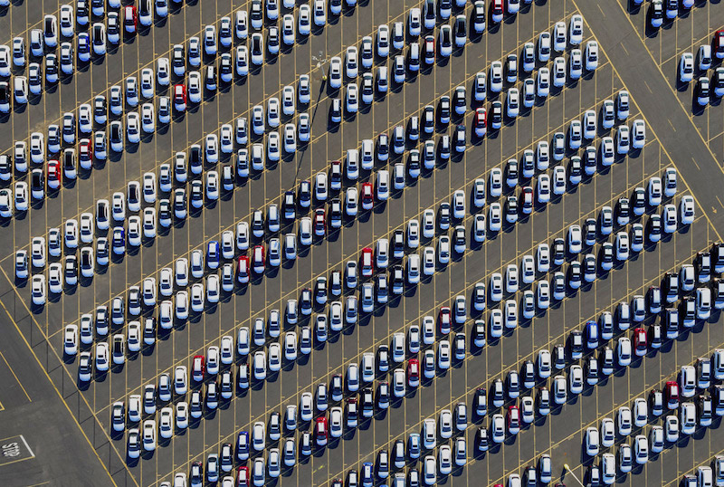

# Applications: Email receipts

Quandl used a panel of email receipts to predict the effects of an Uber platform charge policy.

[figure not shown]

# Applications: Pricing

Zillow collected most of the housing sales data in the US and constructed a price prediction model to help sellers price their homes more competitively when they choose to put the property on the market.

[figure not shown]

# Applications: Fire Prediction

FDNY among other city fire departments around train algorithms to predict where fires will in order to target fire safety inspections.

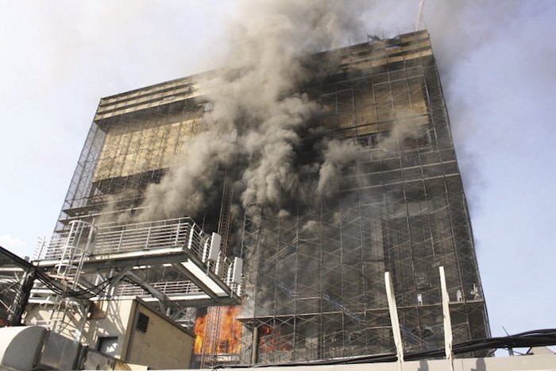

# Applications: Anomaly Detection

Advanced time series modeling can be used to detect anomalous activity so that online platforms can safeguard their assets.

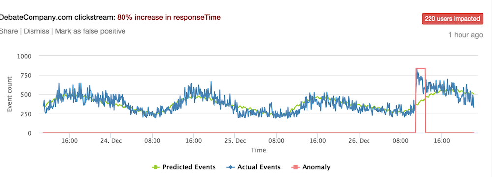

# What’s the pattern!

All of these examples have a common structure.

**What is the underlying structure?**

# Detect the pattern!

- Implies there is an **end user**
- The end user has a **problem**
- **Data** is available
- A **model** is used to power the solution
- The result is **scalable** and, if necessary, **automated**.

# Applications: BEA

### What are some good uses of this paradigm at **BEA**?

# Applications: BEA

### What are some good uses of this paradigm at **BEA**?

- Advanced algorithms for constructing synthetic source data from more timely data in order to reduce revisions
- Anomaly detection applied to source data to flag for analyst quality control review
- Automated model-based imputation that reduces need for manual adjustments
- News correlation engine to help tell the story behind movements in the data

# What is it we’re talking about?

Data science has a rather fluffy definition as it is interdisciplinary field. But generally, there is agreement that *data science* sits at the intersection of mathematical inference, computer science and subject matter expertise.

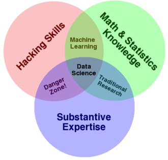

Venn diagram by Drew Conway

# How is data science different from other fields?

Data science uses statistical inference and computational algorithms to develop applications that communicate an actionable insight.

$$\text{Data Science} = f(\text{Statistics, Computer Science})$$

Modern statisticians will claim that data science is no different, but they tend not to operationalize insight. Computer scientists have long developed applications, but are not interested in inference.

$$\text{Statistics} \neq \text{Computer Science}$$

Data science is not social science as it does not rely on formal social theories, but rather starts from the first principles of inference from data.

$$\text{Data Science} \neq \text{Social Science}$$

# What is data science good for? Where does it fall short?

|  | Yea | Nay |
| --- | --- | --- |
| Adoption | Embraced mostly in fields where there is a rapid expansion of data and theory has not yet formed | Data science tends to clash with well-established fields. |
| Interpretation | Underlying skills can be flexibly applied | There isn’t a gold standard for how it should be applied. |
| Staffing need | Very few people required to do the job well | Fluffy definition means little quality control of who is a data scientist |
| Long term outlook | Skills will likely persist into the future | Whereas early days of data science focused on generalist practitioners, future practitioners will be field specific – re-adsorbed into host field. |

# Data Science vs. Economics vs. National Accounts

- Economics and National Economic Accounting are well-established fields with standardized toolsets.

2. Most data analysis is intended to crafted a narrative about the trends, which in turn could inform policy and general strategy. Data science gives a voice to the micro details and enables tactical level decisions.
- Example: Data analysis on e-commerce sales could indicate that Nintendo Switch out sold XBoxes. A data science project figures out who should Nintendo and Microsoft products be targeted to, their price point, and at what time of the day.

# Why economists make for good data scientists?

Data science has been hyped to be the panacea for business and policy. But in the end, it’s just a different brand of statistics that has direct applications for end users. The technologies are getting easier to use, requiring only a fraction of the training that experts did decades ago.

What’s left is asking good questions. That best data scientists are those who can find a problem, break it apart, then figure out what can data do to solve it as well as know when data is useless.

Economists are good at asking questions.

# Why is data science good for BEA?

# What makes for a good application?

Applications tend take on one of three forms:

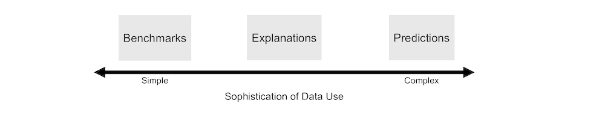

In other words, what we do with the data needds to have a point.

# What is the difference between theory-driven and data-driven approaches?

Story-driven

- Models are constructed following a formal theory
- Objective tends to describe phenomena, but model accuracy tends not to be a primary consideration

Data driven assumes that we rely on math to uncover relationships

- Assume that the data that are considered are relevant, but models have properties that can surface relationships
- More focused on prediction

# Example: Story-Driven vs. Data-Driven

- Story-Driven: story about regression that has significant coefficients but very low R-squared, coefficients then tell a story.
- Data-Driven: story about prediction that has very high accuracy, but model is not linearly interpretable and thus story is not clear

# So so so many buzzwords

Data science is also a marketing term and part of a larger universe of buzzwords:

- **Big Data**
- **Data analytics**
- **Machine Learning**
- **Artificial Intelligence**
- **Data engineering**
- **Deep learning**

# So so so many buzzwords

Data science is also a marketing term and part of a larger universe of buzzwords:

- **Big Data**: Data that tends to be available at a high frequency (velocity) with a large quantity (volume), and capturing a broad set of information (variety)
- **Data analytics**: Process of analyzing and surfacing insights from data.
- **Machine Learning**: Statistical techniques that allow computers to learn patterns.
- **Artificial Intelligence**: See above, but applied to solving human tasks.
- **Deep learning**: A branch of machine learning concepts and representations rather than tasks.
- **Data engineering**: Process of engineering software solutions and pipelines for data.

# What is data science entail?

Focused on engineering reliable systems and processes that automate replicable and stable science

Allows data to take a more active and precise role in operations, rather than requiring human judgment screen each and every step of a task, but allows well-calibrated and designed algorithms to learn patterns in order to make good predictions

# How are data science projects typically structured?

[interactive chart not shown]

Note: Different companies will have a different ways of describing this process – it’s largely for marketing purposes, but is effectively the same.

# (1) Use Case Statement

Set the initial starting parameters by answering these questions

- **What discretely defined problem exists?**
- **Who specifically does the problem effect?**
- **Under what conditions does the problem exist?**
- **Which aspects of the problem lend itself to data solutions?**
- **What can be engineered to improve the situation?**
- **What are the success criteria?**

# (1) Use Case Statement: Example

- **What discretely defined problem exists?** *NEA would like to reduce revisions where possible*.
- **Who specifically does the problem effect?** *PCE branch sits on top 70% of the GDP – start there*.
- **Under what conditions does the problem exist?** *Advance estimates are produced prior to receiving Census data*.
- **Which aspects of the problem lend itself to data solutions?** *Enhanced forecasts using contemporaneous data*.
- **What can be engineered to improve the situation?** *A forecast system that evaluates all available information in a timely manner in order to produce synthetic source data* .
- **What are the success criteria?** *Resulting predictions must be closer to the 3rd estimate than current method.*

# (2) Data Acquisition

# (2) Data Acquisition: Example

# (3) Data Engineering

# (3) Data Engineering: Example

# (4) Modeling

# (4) Modeling: Example

# (5) Deployment

# (5) Deployment: Example

# Not Rube Goldberg

This sounds too complicated for everyday use.

The beauty of modern technology and techniques is that it can turn tedium into something that is surefire. The goal is to engineer a machine that produces artisan-quality results at the click of a button.

[figure not shown]

# rubeGoldberg()

- co-developed with engineering and economists
- overseen by a product team that understands how data products will be used by customers.

Everyone tends to know the same code base (e.g. “We are a Python shop”)

[interactive chart not shown]

# Part II: Code Refresher

Data science generally relies on one of two coding languages: **R** and **Python**.

Today, we will have a quick refresh of R and walk through two basic scripts that represent how a basic data science project could work.